# A1 - Neighborhood Score: Benchmarking Report

Dhvani Sheth

September 21, 2017

The k (neighborhood) considered here is 2

### Explain the difference in the execution profiles among variants

Sequential Variant

In this, the program runs on only one main thread. Every subsequent execution step is processed after the previous step is processed.

1. Read all files one at a time. While reading each file, remove all characters except letters a to z and space.
2. Keep a count of total characters (henceforth characters and letters are used interchangeably) in a file. Also, keep a count of the number of occurrences of each letter in the file.
3. Both the above parameters are updated as we go through each file.
4. After all the files are processed, we have the total number of characters in the whole corpus.
5. We now also have the total occurrences of each character.
6. Now we calculate score of each letter.
7. Iterate through each file one by one. Calculate word score and store it. Get neighborhood of every word in a file (for a repeating word, append the neighbors) and store it.
8. Calculate the mean neighborhood score for each word in a file and store it in a hash map.
9. Do the above for each file. Now we have the neighborhood score of every word in each of the files.
10. Now go through the neighborhood score generated hash map and append the score for each word.
11. Output the word and its mean score (we have score of the word from each file, thus get the mean) to a CSV file.

Parallel Variant

In this, the program is run in such a way that some parts of it are executed parallelly. We create a thread pool with number of threads varying from 2 to 16. So for example, if the thread pool size is 2, we have 2 threads running parallelly. We can create a thread pool of 20 threads too, however, internally the number of threads running in parallel is equal to the number of logical processors.

1. Read all files parallelly with the number of threads given as input. For each file, remove all the characters except letters a to z and space. Store this word in a list of string. Since we are storing it in one list, access to this list is synchronized meaning only one thread can access it at a time.
2. Now for each file in, keep the count of the total number of characters and the number of occurrences for each character for every thread.
3. After all the threads have been executed, combine the number of occurrences for every character and the count of characters. Now get the score for each character.
4. Again, process all files in parallel. Calculate the word score. Get the neighbors of each word in a file. Calculate the mean neighborhood score of every word and store it for each thread.
5. After all the threads have completed executing, combine the scores of each word from every other file and output the word and its mean neighborhood score in a csv file.

### Comment on the differences in performance of the sequential and parallel/concurrent variants

X-axis is the number of iterations. Y-axis is the execution time for each iteration in seconds.

Graph for Sequential run:

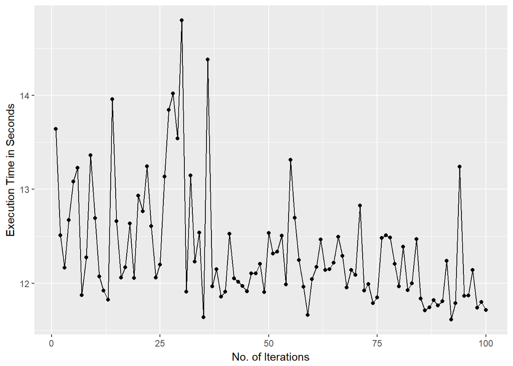

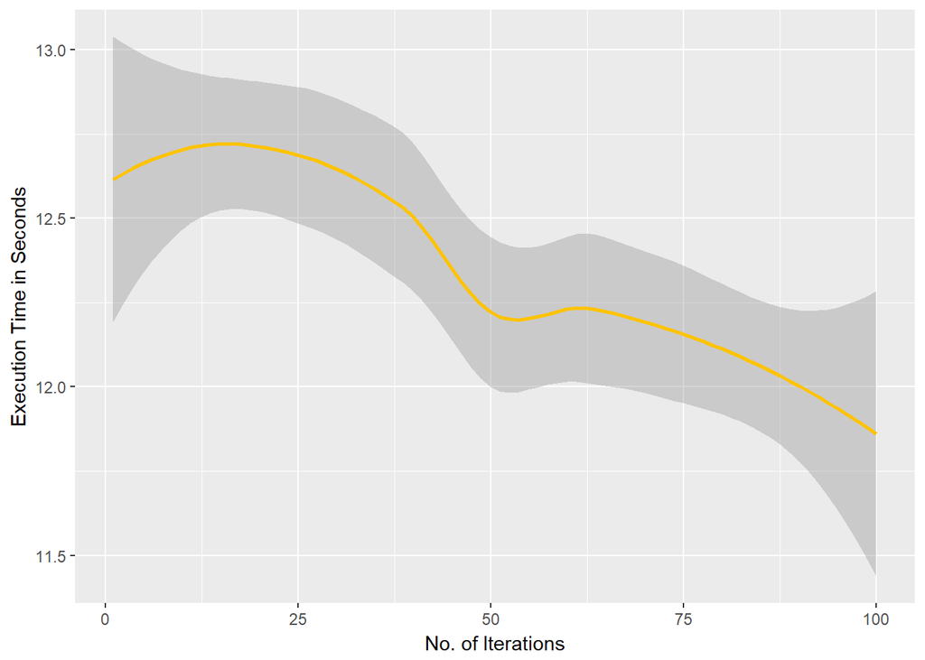

Graph for Parallel run:

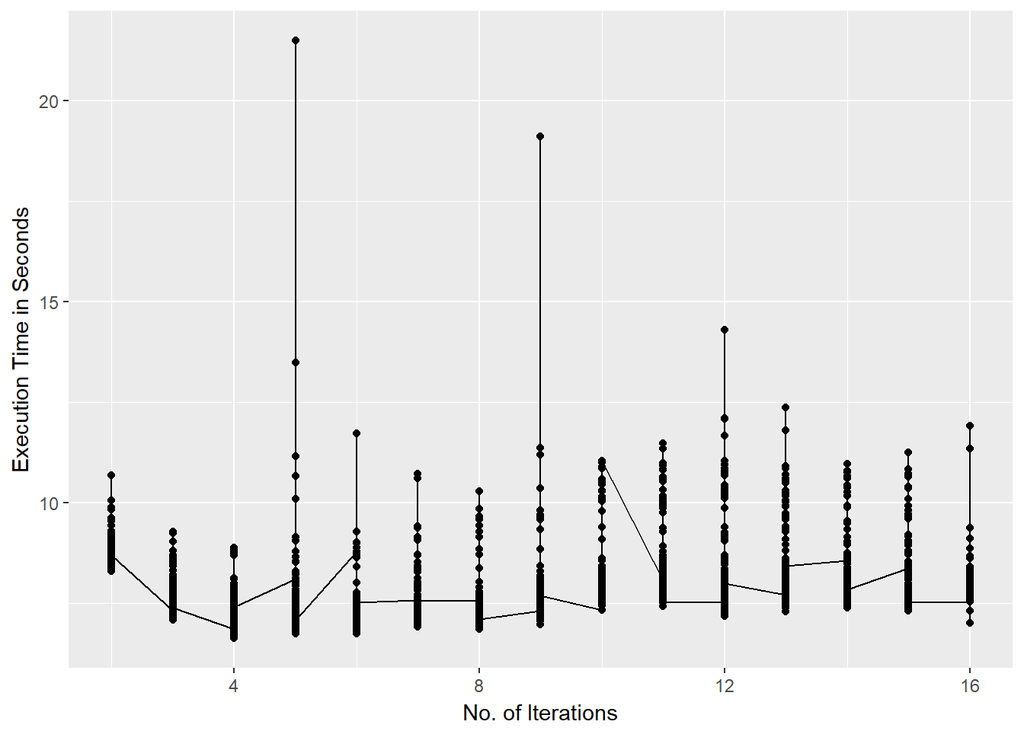

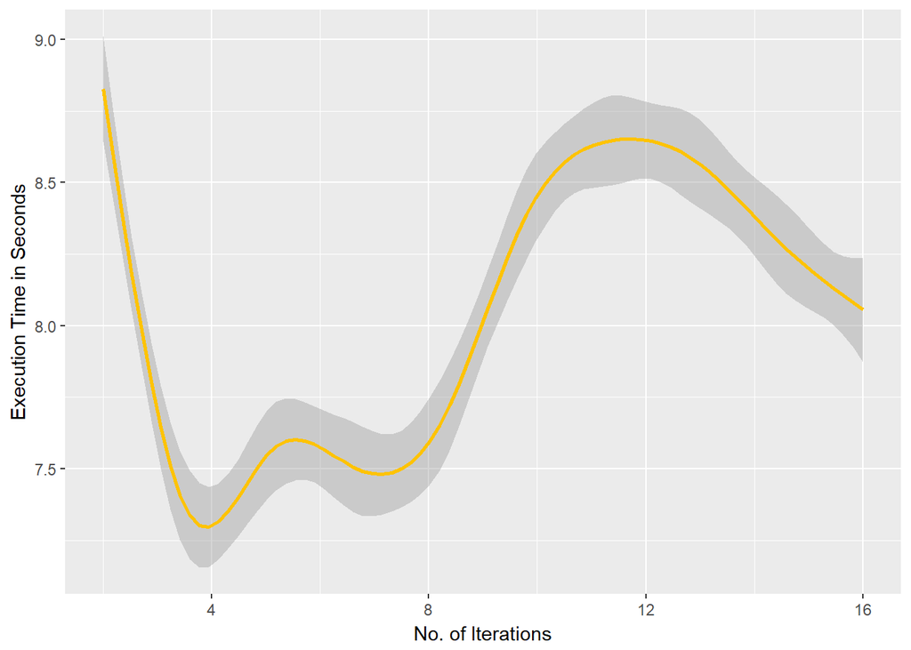

### Comment on the impact of the number of executor threads on performance

Below is the mean for each of the threads 2 - 16

```
##    ThreadNumber    Time
## 1             2 8.84973
## 2             3 7.69058
## 3             4 7.21235
## 4             5 7.68271
## 5             6 7.46439
## 6             7 7.55691
## 7             8 7.55695
## 8             9 7.99225
## 9            10 8.48743
## 10           11 8.64108
## 11           12 8.61360
## 12           13 8.59039
## 13           14 8.37640
## 14           15 8.19190
## 15           16 8.05927
```

### Explain which implementation variant and configuration have the best combination of performance and stability.

Below is the mean for the sequential execution

```
## [1] 12.35783
```

Below is the mean for the parallel execution

```
## [1] 8.064396
```

### Specifications of the execution environment:

Java version: Version 8 Update 111 (build 1.8.0_111-b14)

OS version:

Edition: Windows 10 Home

Version: 1703

OS Build: 15063.608

Hardware specs:

Processor: Intel Core i7-6500U

RAM: 12GB

Cores: 2

Logical Processors: 4